# COMM 3710: Presenting Research

# Some Guidelines for Writing and Presenting Research

> What is your story? 📓

Your research tells a story. Before you start writing paper or creating a research presentation, you should have an **outline**in mind.

# The Anatomy of a Scientific Paper/Presentation

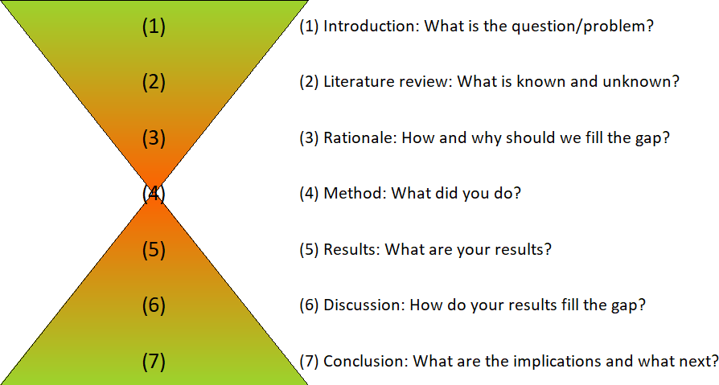

We will use the following journal article as an example:

> Yeo, S. K., Su, L. Y.-F., Cacciatore, M. A., McKasy, M., & Qian, S. (2020). Predicting intentions to engage with scientific messages on Twitter: The roles of mirth and need for humor. Science Communication, 42(4), 481–507. https://doi.org/10.1177/1075547020942512

Obtain a PDF of the article using the library resources available through the [Marriott Library](https://lib.utah.edu).

Of course, your presentation should always include a descriptive title and the authors’ names.

[figure not shown]

# Introduction

Introduce the problem and the context of your research, i.e., set the stage for your study. You can do so by briefly describing the **social significance** of your research question/problem.

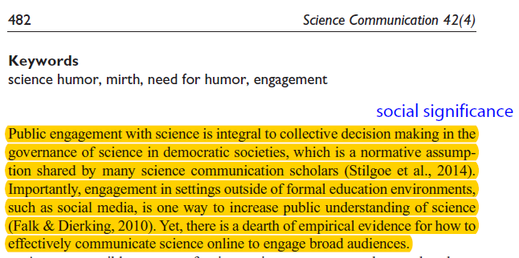

Describe the **academic or scholarly significance** of the research that you are presenting.

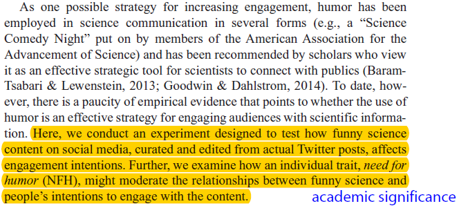

Identify the **specific contribution** of your study to the existing body of scholarly work and/or social context.

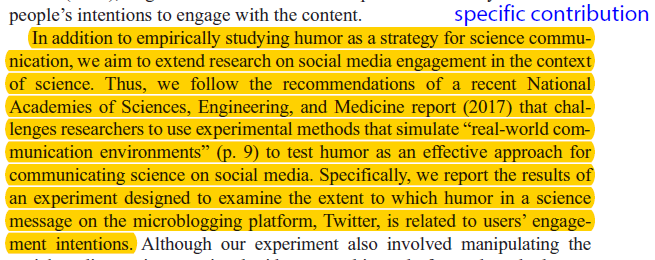

# Literature Review and Rationale

In this section, you should review the existing scholarship that is relevant to your research question. The review of the literature often covers the key concepts in your study and often culminates with specific hypotheses and/or research questions.

An example of this can be seen below:

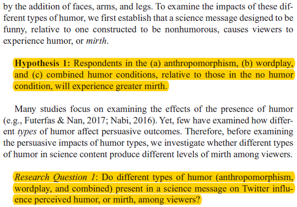

The literature review should contain brief descriptions of theories that are applicable to your study. This is part of the **rationale** of your study.

# Method

The Method section describes the **what** and **how** of your research. In other words, it is the operationalization of your research–it is often the easiest section to write since it is a literal description of what you did in the study. It should include a description of your **sample**, the **experimental design (if your study is experimental)**, the **measures** used in the study, and the **data analysis**.

As you can see in the Yeo *et al.* (2020) article, the first paragraph of the Method section describes the sample:

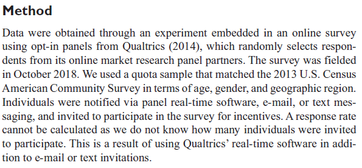

Then, a detailed description of the experiment is included in the article:

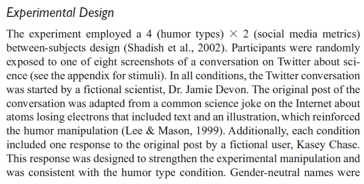

This is followed by a description of how the key variables that represent important concepts in the paper were measured or operationalized:

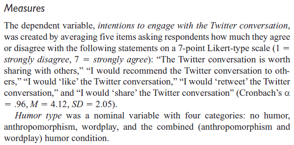

To close the Method section, a description of how the data were analyzed is included:

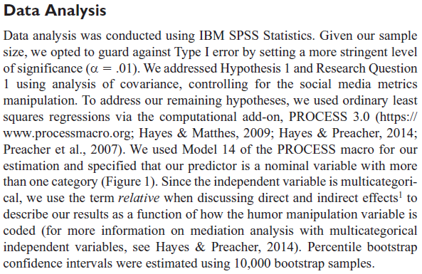

# Results

In this section, you will use the data to address the hypotheses and research questions that you posed in the Literature Review and Rationale. You should use tables and figures as appropriate.

As you can see from the example below, this section includes the statistical results of various analyses that address the specfic hypotheses and research questions:

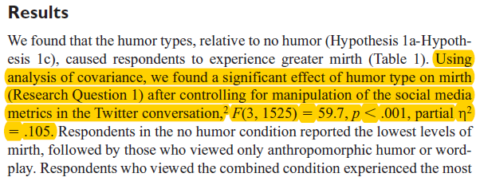

In our example, the authors used a regression model to analyze their data. As a result, they included a table showing the results of the regression model:

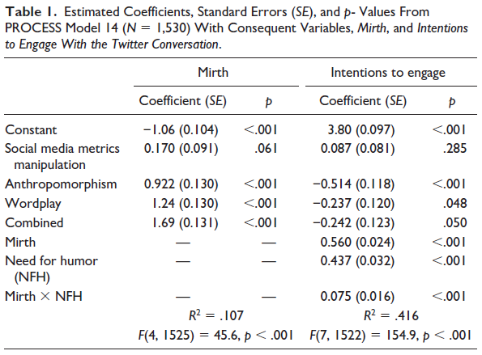

Relevant figures should also be included in this section and referenced within the text:

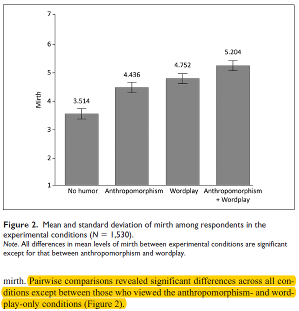

# Discussion and Conclusion

This section often begins with a brief restating of the overarching goals of the study. Then, some authors opt to describe the limitations of their study prior to discussing the implications of their findings. There is no “correct” way to order the Discussion, but a good discussion of a research study should always include limitations and shortcomings.

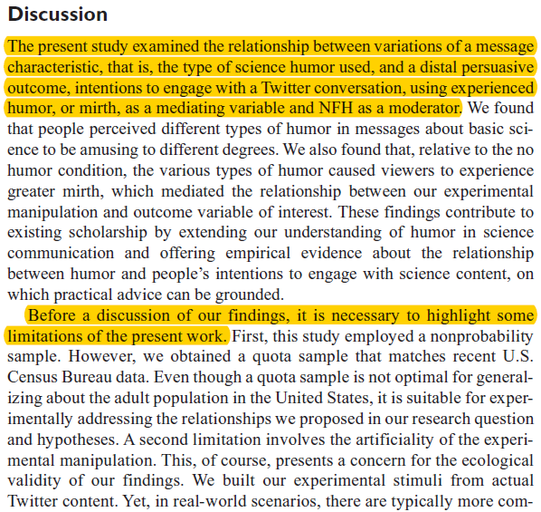

Finally, the discussion of the findings and their implications should lead to some thoughts for future research and any additional questions the research might raise.

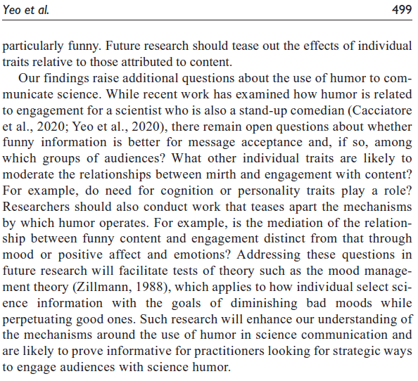

# Presentations vs. Papers

Although we used a scientific paper as an example here, the principles and sections apply to creating research presentations as well. One major difference is that there are aesthetic considerations to keep in mind when creating a visual presentation instead of authoring a journal article.

Some tips for presentations:

- The average presenter can cover about one slide per minute. Plan and practice your talk accordingly, especially if there is a time limit.
- You should only present one idea or topic per slide. This might mean including only a single graph to convey a point on one slide. In this case, less is more.
- The 6 $\times$ 6 rule:
  - Six lines of text per slide
  - Six words per line
- Slides are a focus for your presentation and should not be the whole presentation. It is much easier for your audience to listen to you if they are not also trying to read a slide full of text.
- Practice your talk! All successful presenters have practiced their talk.